# Introduction

## Scientific Question: Does the reduction of protein tyrosine phosphatase receptor type S (PTPRS) expression contribute to breast ductal carcinoma metastasis? If yes, is the Epithermal Growth Factor Receptor (EGFR) mediated EMT (epithelial-mesenchymal transition) pathway involved, or what other pathways are involved?

### Background:

Protein tyrosine phosphatase receptor type S/sigma (PTPRS) is a receptor-type protein tyrosine phosphatase (PTP). Previous studies have shown that PTPRS acts as a tumor suppressor (MacKeigan et al., 2005), and the reduction of PTPRS expression was observed in colorectal cancer (Davis et al., 2018), head and neck cancer (Morris et al., 2011), and hepatocellular carcinoma (Wang et al., 2015). Moreover, PTPRS is suggested to negatively regulate hepatocellular carcinoma metastasis through modulating the Epithermal Growth Factor Receptor (EFGR)-Induced Epithelial-Mesenchymal Transition (EMT) process (Wang et al., 2015). Therefore, I am curious about whether PTPRS is also downregulated in invasive breast cancer cell lines and whether it plays a similar role as a metastasis suppressor as in hepatocellular carcinoma.

This project focus on the mRNA expression differences between cancer cell lines of two breast cancer types, invasive ductal carcinoma and breast ductal adenocarcinoma, as a way to investigate whether PTPRS is downregulated in the invasive cell line and contributes to cancer metastasis. RNA-seq data were obatined from EBI Expression Atlas database and pathway analysis was performed against pathway datasets in Gene Ontology (GO) database.

EMBL’s European Bioinformatics Institute (EMBL-EBI, https://www.ebi.ac.uk/) is an open resource that archives diverse molecular datasets, including nucleotide sequences, protein sequences, gene expression, etc. Specifically, gene and protein expression datasets are assembled in EBI Expression Atlas database (https://www.ebi.ac.uk/gxa/home), providing gene and protein expression data obtained from different species and different biological conditions.

Gene Ontology (GO, http://geneontology.org/) is an open resource that keeps updating a comprehensive and computational model of biological systems across organisms, with an emphasis on biological functions, relative pathways, and cellular locations.

## Scientific Hypothesis: If PTPRS is shown as a metastatic suppressor in hepatocellular carcinoma, then it may also exhibit a similar regulatory role in breast ductal carcinoma and the loss of PTPRS may also contribute to the breast cancer metastasis by regulating similar mediators like EGFR.

The RNA-seq results were obtained from EBI Expression Atlas database. I found this experiment by clicking on the "browse experiment" tab in the mainpage, and search "RNAseq breast" in the "Title" query. The experiment "Variation in RNA expression in a panel of 30 breast cancer cell lines" is the first result of the query and it performed RNA-seq on 30 breast cancer cell lines of Homo Sapiens. To download these file, I first clicked "Downloads" tab in the page of this experiment, and clicked "Expression values across all genes (TPM)" for the file containing TPM count results, and "Expression Design (tsv)" containing information about experimental details. The original files are tsv files, and I converted them into csv files for convenience.

To investigate whether PTPRS is downregulated in invasive breast cancer cell lines, differential expression analysis (RNAseq expression analysis) is first performed to compare the mRNA expression of invasive ductal carcinoma and breast ductal adenocarcinoma cell lines. Differential expression of each gene is determined by calculating the log 2 fold change and p-value. The result of differential expression analysis was visualized in a volcano plot, and genes of interest like PTPRS were marked in the plot to see whether their expression is significantly different between two conditions (invasive ductal carcinoma vs. breast ductal carcinoma).

*(Note: It would be desired to test the hypothesis if I can compare the invasive cancer cell lines with normal cell lines derived from breast tissue as a control. However, due to the limited availability of data, I only obtained RNA-seq data of various cancer cell lines. Therefore, analyses were focus on the diffferential expression between invasive ductal carcinoma and breast ductal carcinoma.)*

In the second part of this project, pathway analysis was performed based on the result of differential expression analysis to investigate which biological pathways are most likely involved in the mRNA expression differences between two types of cell lines and explain the biological phenotype (metastasis).

GO pathway datasets used in pathway analysis were obtained through GSEApy (Gene Set Enrichment Analysis in Python) package, so there is no need to download data.

# Loading in Packages

- **pandas**: Pandas is a python package and is based on Numpy. Pandas can handle various type of input data. It helps to structure data and perform analysis efficiently. In this project, csv files will be read with pandas and stored as pandas two-dimensional dataframes. To learn more about pandas see here: https://pandas.pydata.org/docs/getting_started/overview.html.
- **NumPy**: NumPy is a widly used python package. It accept diverse data types, including integer, boolean, float, and more. NumPy helps to organize and store data in a variety of data structures like array and matrix. NumPy also provides all kinds of operations to manage data like mathetical operation and logical operation. To learn more about NumPy see here: https://numpy.org/doc/stable/.
- **SciPy**: SciPy is a python package that is based on Numpy. Scipy includes abundant mathematical algorithms and functions that are commonly used in science. These algorithms and functions are stored in subpackages like stats. In this project, Stats subpackage of SciPy will be used to perform T-test and calculate p-values in differential expression analysis. To learn more about SciPy see here: https://docs.scipy.org/doc/scipy/tutorial/index.html#user-guide.
- **statsmodels**: Statsmodels is a python package. It can estimate one statistical model and visualize the result. It can also be used to perform statistical analysis. Statsmodels package handles R-style formulas and pandas DataFrames. In this project, the multipletests function of statsmodels package will be applied to correct p-values and return the adjusted p-values. To learn more about statsmodels see here:https://www.statsmodels.org/dev/index.html.
- **bioinfokit**: Bioinfokit is a pythonpackage that is based on several packages like Numpy, pandas, matplotlib, etc. It can perform various type of analysis on biological data like gene expression normalization, variant analysis, high-throughput sequence analysis, biostatistical analysis, etc. Bioinfokit also have modules that can visualize the biological data in volcano plot, heatmap, etc. In this project, bioinfokit package will be used to visualize the result of differential expression analysis as a volcano plot. To learn more about bioinfokit see here: https://pypi.org/project/bioinfokit/.
- **GSEApy**: GSEApy is a python package that combined GSEA (Gene Set Enrichment Analysis) and Enrichr. GSEApy can analyze results of RNA-seq, ChIP-seq, and Microarray. In this project, the enrichr module of GSEApy will be used to obtain GO datasets and perform pathway analysis. Results of pathway analysis will also be ploted using GSEApy barplot module. To learn more about GSEApy see here: https://gseapy.readthedocs.io/en/latest/introduction.html.
- **matplotlib**: Matplotlib is a python package. Similar to MATLAB, matplotlib is developed to visulaize data. However, matplotlib is different as it can interact with Python, NumPy, and many NumPy based packages. Matplotlib visualizes the result in a figure and contains various functions to optimize the data visualization. To learn more about matplotlib see the tutorial page here: https://matplotlib.org/stable/tutorials/index.html.

```python
pip install bioinfokit
```

```python
pip install gseapy
```

```python
#import packages and modules
import matplotlib.pyplot as plt
import pandas as pd
import numpy as np
from scipy import stats
from statsmodels.sandbox.stats.multicomp import multipletests
from bioinfokit import analys, visuz
import gseapy as gp
from gseapy.plot import barplot
```

# Part 1 Load in data

```python
#read in read count csv file download from EBI expression atlas database
#define as a global variable rna_raw
rna_raw=pd.read_csv('30_breast_cancer_rna_TPM.csv')
#rna_raw.head() #uncomment to check original dataframe
rna_raw = rna_raw.fillna(0) #replace NaN values with 0
#define a global variable rna_adjust that drop the column "Gene_ID" and set "Gene_Name" as index
rna_adjust =rna_raw.drop(columns = "Gene_ID").set_index("Gene_Name")
#rna_adjust.head() #uncomment to check adjusted dataframe

#read in experimental design csv file download from EBI expression atlas database
#define as a global variable rna_metadata
rna_metadata= pd.read_csv('30_breast_cancer_rna_experiment_design.csv')
#rna_metadata.head() #uncomment to check dataframe
rna_metadata= rna_metadata.set_index("Sample Characteristic[cell line]") #set cell line name as index
#rna_metadata.head() #uncomment to check dataframe

#select the disease type column and define as a global variable disease
disease= rna_metadata["Sample Characteristic[disease]"]
disease_type= pd.DataFrame(disease) # define the new dataframe containing the disease type column as a global variable disease_type
disease_type= disease_type.rename(columns= {"Sample Characteristic[disease]" : "disease_type"})#rename column name as disease_type
disease_type= disease_type.replace(regex=[' '], value='_') #replace space with underscore
#disease_type.head() #uncomment to check dataframe
```

# Part 2A

### Bioinformatics Analysis: Differential Expression Analysis (RNAseq)

### Database: EBI

Differential expression analysis handles normalized read count result from experiments like RNA-seq and microarray, and investigate the expression differences between two experimental conditions by calculating the log2 fold change and p-value of each transcript or gene. Log2 fold change reveals the difference between two conditions, while the p-value indicates whether the observed difference is significant or it is a random event.

Read counts are usually normalized in three ways, RPKM (Reads Per Kilobase Million), FPKM (Fragments Per Kilobase Million), or TPM (Transcripts Per Million). RPKM and FPKM first divide the total count by one million as a scaling factor and then normalize the sequencing depth by dividing read counts by the scaling factor. Next, gene length will be normalized by dividing the normalized value by gene length in kilobases. RPKM is for single-end RNA-seq, while FPKM is for paired-end RNA-seq. TPM is different from RPKM and FPKM as it first normalizes the gene length, and then normalizes the sequencing depth. TPM is beneficial as all the total TPM of each sample or experimental condition are the same and it is easier to compare the expression differences between samples. For more explanation about the read count normalization see here: https://www.rna-seqblog.com/rpkm-fpkm-and-tpm-clearly-explained/.

Due to the incompatibility of Python version and DESeq2 package, differential expression analysis will be performed explicitly here. A csv file containing normalized mRNA expression counts (TPM: Transcripts Per Million) of several conditions (disease types) is first read in as a pandas dataframe and organized based on disease types. After calculating the sum, mean, and standard deviation of mRNA expression of invasive ductal carcinoma and breast ductal adenocarcinoma cell lines, Log2 fold change, p-value, and adjusted p-value are calculated for each gene and stored in new columns.

```python
#define an array of unique disease types as a global variable unique_type
unique_type = disease_type['disease_type'].unique()
#print(unique_type) #uncomment to check correct unique_type array

#Run a for-loop to turn cell lines of each disease type into separate lists
for i in unique_type:
    string = i
    globals()[string] = list(disease_type.loc[disease_type['disease_type'] == string].index) #define global variables name as each disease type in unique_type
    print (globals()[string]) #each list is stored in a global variable named as the corresponding disease type, can be recalled with the variable

#print(breast_adenocarcinoma) #uncomment to check correct global variable output of for-loop
```

```
['BT20', 'BT474', 'BT549', 'HCC1187', 'HCC1395', 'HCC1419', 'HCC1500', '-MCF\xa07.00', 'MDAMB436', 'ZR7530']
['CAL120', 'CAMA1', 'MDAMB231', 'MDAMB361', 'MDAMB453', 'MDAMB468', 'SKBR3']
['CAL148', 'CAL51', 'HS578T', 'MFM-223', 'MDAMB157', 'SKBR7']
['HCC1569']
['HCC1806']
['HCC1937', 'HCC1954', 'HCC38', 'HCC70', 'T47D']
```

```python
# Calculate the sum of the reads for each gene for invasive ductal carcinoma and breast ductal adenocarcinoma
#and store the result in new columns
rna_adjust['Sum_invasive_ductal_carcinoma'] = rna_adjust[invasive_ductal_carcinoma].sum(axis=1)
rna_adjust['Sum_breast_ductal_adenocarcinoma'] = rna_adjust[breast_ductal_adenocarcinoma].sum(axis=1)

# Calculate the mean of the reads for each gene for invasive ductal carcinoma and breast ductal adenocarcinoma
#and store the result in new columns
rna_adjust['Mean_invasive_ductal_carcinoma'] = rna_adjust[invasive_ductal_carcinoma].mean(axis=1)
rna_adjust['Mean_breast_ductal_adenocarcinoma'] = rna_adjust[breast_ductal_adenocarcinoma].mean(axis=1)

# Calculate the standard deviation of the reads for each gene for invasive ductal carcinoma and breast ductal adenocarcinoma
#and store the result in new columns
rna_adjust['STD_invasive_ductal_carcinoma'] = rna_adjust[invasive_ductal_carcinoma].std(axis=1)
rna_adjust['STD_breast_ductal_adenocarcinoma'] = rna_adjust[breast_ductal_adenocarcinoma].std(axis=1)

#print(rna_adjust.head()) #uncommment to check correct new columns
```

```python
#define a function Log_Fold_Change(df, a, b)
def Log_Fold_Change(df, a, b):
    #a function that takes two string (a and b) of column names of interest in a dataframe (df),
    #and calculate the log2 fold change of each row of column a over column b.
    #Store the result in a new column names as 'L2F'.
    Fold_change = df[a]/df[b] #define a local variable Fold_change
    df['L2F'] = np.log2(Fold_change) #create a new column in df name as 'L2F', storing the calculated log2 fold change values

    #np.log2() function takes an array of values and return an array of base-2 logarithm of the input values.

# apply the function on 'Sum_invasive_ductal_carcinoma' and 'Sum_breast_ductal_adenocarcinoma' columns in rna_ajust.
Log_Fold_Change(rna_adjust, 'Sum_invasive_ductal_carcinoma', 'Sum_breast_ductal_adenocarcinoma')
#print(rna_adjust.head()) #uncommment to check correct new columns

rna_adjust.replace([np.inf, -np.inf], 0, inplace=True) #replace inf/-inf value in L2F column with 0

# calculate p-values for each gene using a lambda function performing T-test for means of two independent samples
# store the p-values in a new column 'pval'
rna_adjust['pval'] = rna_adjust.apply(lambda x: stats.ttest_ind_from_stats(x['Mean_invasive_ductal_carcinoma'],x['STD_invasive_ductal_carcinoma'],x['Sum_invasive_ductal_carcinoma'], x['Mean_breast_ductal_adenocarcinoma'],x['STD_breast_ductal_adenocarcinoma'],x['Sum_breast_ductal_adenocarcinoma'])[1],axis=1)
#rna_adjust.head() #uncomment to check new column
rna_adjust = rna_adjust.fillna(0) #replace NaN value in pval column with 0

#calculate adjusted p-values for each gene using the conservative Bonferroni correction method
#which multiplies the raw P values by the number of tests m
#store the adjusted p-values in a new column 'padj'
pd.set_option('display.float_format', lambda x: '%.20f' % x) #change format to avoid scientific notation
rna_adjust['padj'] = multipletests(rna_adjust['pval'], alpha=.05, method='bonferroni')[1] # alpha: family-wise error rate

rna_adjust.head() #check correct dataframe format with new columns
```

| Gene_Name | BT20 | BT474 | BT549 | CAL120 | CAL148 | CAL51 | CAMA1 | HCC1187 | HCC1395 | HCC1419 | ... | ZR7530 | Sum_invasive_ductal_carcinoma | Sum_breast_ductal_adenocarcinoma | Mean_invasive_ductal_carcinoma | Mean_breast_ductal_adenocarcinoma | STD_invasive_ductal_carcinoma | STD_breast_ductal_adenocarcinoma | L2F | pval | padj |
| --- | --- | --- | --- | --- | --- | --- | --- | --- | --- | --- | --- | --- | --- | --- | --- | --- | --- | --- | --- | --- | --- |
| TSPAN6 | 20.00000000000000000000 | 10.00000000000000000000 | 23.00000000000000000000 | 46.00000000000000000000 | 39.00000000000000000000 | 101.00000000000000000000 | 16.00000000000000000000 | 94.00000000000000000000 | 23.00000000000000000000 | 5.00000000000000000000 | ... | 19.00000000000000000000 | 262.00000000000000000000 | 301.00000000000000000000 | 26.19999999999999928946 | 60.20000000000000284217 | 24.77364190694079582045 | 22.28676737438608412845 | -0.20019667522225170764 | 0.00000000000000000000 | 0.00000000000000000000 |
| TNMD | 0.00000000000000000000 | 0.00000000000000000000 | 0.00000000000000000000 | 0.00000000000000000000 | 0.00000000000000000000 | 0.00000000000000000000 | 0.00000000000000000000 | 0.69999999999999995559 | 0.00000000000000000000 | 0.00000000000000000000 | ... | 0.00000000000000000000 | 0.69999999999999995559 | 0.00000000000000000000 | 0.06999999999999999278 | 0.00000000000000000000 | 0.22135943621178658103 | 0.00000000000000000000 | 0.00000000000000000000 | 0.00000000000000000000 | 0.00000000000000000000 |
| DPM1 | 236.00000000000000000000 | 268.00000000000000000000 | 178.00000000000000000000 | 247.00000000000000000000 | 182.00000000000000000000 | 152.00000000000000000000 | 103.00000000000000000000 | 99.00000000000000000000 | 301.00000000000000000000 | 586.00000000000000000000 | ... | 108.00000000000000000000 | 2456.00000000000000000000 | 977.00000000000000000000 | 245.59999999999999431566 | 195.40000000000000568434 | 136.95676527851975379235 | 54.19686337787454988302 | 1.32988009340179402784 | 0.00000000000000000000 | 0.00000000000000000000 |
| SCYL3 | 15.00000000000000000000 | 32.00000000000000000000 | 7.00000000000000000000 | 5.00000000000000000000 | 26.00000000000000000000 | 10.00000000000000000000 | 20.00000000000000000000 | 11.00000000000000000000 | 8.00000000000000000000 | 19.00000000000000000000 | ... | 22.00000000000000000000 | 155.00000000000000000000 | 70.00000000000000000000 | 15.50000000000000000000 | 14.00000000000000000000 | 7.56086414814250318273 | 3.31662479035539980998 | 1.14684138832927118301 | 0.11310236759640826532 | 1.00000000000000000000 |
| C1orf112 | 15.00000000000000000000 | 30.00000000000000000000 | 26.00000000000000000000 | 16.00000000000000000000 | 45.00000000000000000000 | 21.00000000000000000000 | 15.00000000000000000000 | 22.00000000000000000000 | 16.00000000000000000000 | 12.00000000000000000000 | ... | 10.00000000000000000000 | 189.00000000000000000000 | 138.00000000000000000000 | 18.89999999999999857891 | 27.60000000000000142109 | 7.72370089759796218942 | 5.41294744108974335006 | 0.45371796744290371350 | 0.00000000000000000000 | 0.00000000000000000001 |

5 rows × 39 columns

# Part 2B:

### Analysis method: Volcano plot

A volcano plot is a two-dimensional scatter plot of log2 fold change (x-axis) and negative log10 of p-value (y-axis). It visualizes the gene expression changes of two samples or experimental conditions and helps to easily identify the statistically significant changes. Points that have positive log2 fold change are genes that express more in one condition than the other, and vice versa. The wider dispersion from the center indicates larger expression changes of a gene between two conditions. The higher a point is in a volcano plot, the lower is the corresponding p-value, indicating the expression of the gene is more significantly different between two conditions.

In this section, we will apply visuz module in bioinfokit package to generate a volcano plot based on the result of differential expression analysis. A pandas dataframe containing gene names, log2 fold changes, p-values, and adjusted p-values will be used for the volcano plot. A tuple of genes of interest is also created to mark thoes genes in the volcano plot to test the scientific hypothesis. The volcano plot will plot log2 fold change (x-axis) against log10 of the adjusted p-value (y-axis) calculated in part 2A.

To test whether PTPRS is downregulated in invasive cell lines and regulates EGFR-mediated EMT process as observed in hepatocellular carcinoma, we will focus on genes encoding for PTPRS, EGFR, and pro-EMT molecules like Snail, Slug, vimentin, and alpha-SMA.

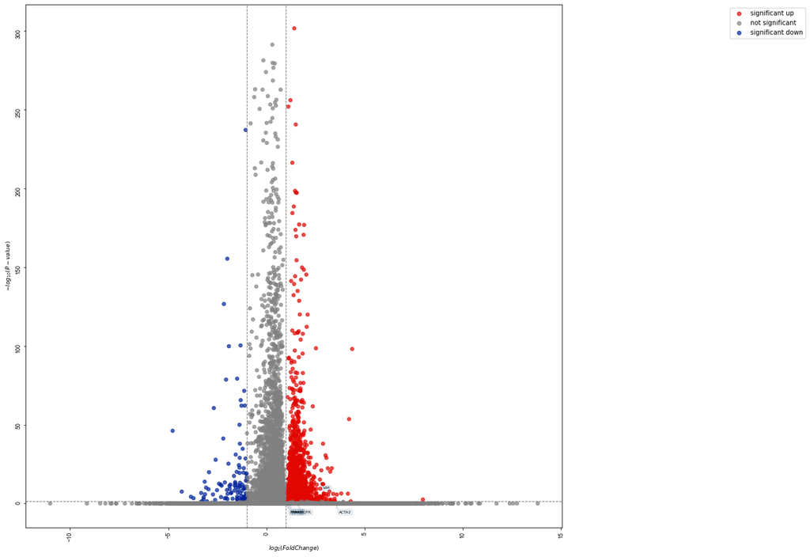

```python
#define a pandas dataframe containing L2F, pval, and padj columns as a globle variable df
df = rna_adjust.iloc[:,-4:]
df = df.reset_index() #reset index to have Gene_Name column
#print(df.head()) #uncomment to check correct data frame

#define a tuple of genes of interests as a global variable EMT
#SNAI1: Snail, SNAI2: Slug, VIM: vimentin, ACTA2: alpha-SMA
EMT = ('EGFR','PTPRS','SNAI1','SNAI2','VIM', 'ACTA2')
#define a tuple of colors as a global varaible color
#(significant up: red, no significant: grey, significant down: blue)
colors =("#E10600FF", "grey","#00239CFF")

#visualize the differential expression analysis result store in df as a volcano plot
visuz.GeneExpression.volcano(df=df, #differential expression analysis result
                             lfc='L2F', #log2 fold change
                             pv='padj', #adjusted p-value
                             color= colors, #colors for
                             valpha=0.7,#transparency of the dot
                             dotsize=30, #dot size
                             geneid ='Gene_Name', genenames = EMT, gstyle=2, #add gene labels for genes of interest
                             sign_line=True, #add threshold lines
                             plotlegend=True,legendpos='upper right', legendanchor=(1.46,1), #add legend
                             dim = (15,15), #adjust figure size
                             show=True) #show volcano plot
```

# Part 2C: Analyzing the Result

The volcano plot above shows the mRNA expression differences between invasive ductal carcinoma and breast ductal adenocarcinoma cell lines. X axis represents log2 fold change, while y axis represents the negative log10 of p-value. Red points represents genes that had significantly more expression in invasive ductal cacrcinoma cell lines than breast ductal adenocarcinoma cell lines. Blue points represents genes that had significantly less expression in invasive ductal acrcinoma cell lines than breast ductal adenocarcinoma cell lines. Grey points represents genes that did not express differently between cell lines of two breast cancer type. As marked in the plot, PTPRS and most EGFR-mediated EMT process relative genes did not show significant expression differences between two breast cancer type. Although the fold change of these genes indicates that the expression level of these gene is higher in invasive ductal carcinoma cell lines, the p-value is not low enough to confirm it is not due to a random event. Only one gene, VIM (vitmentin), is colored in red and expressed significantly more in invasive ductal carcinoma cell lines. The higher expression of vitmentin is expected as it encodes for molecule that promote EMT process for invasion and metastasis.

Overall, this volcano plot suggests that PTPRS is not downregulated in invasive ductal carcinoma cell lines when compares to breast ductal adenocarcinoma cell lines. Therefore, PTPRS may not or merely contribute to breast ductal carcinoma metastasis and denies the scientific hypothesis. Moreover, the propensity to metastasis of invasive ductal carinoma is less likely to be regulated through EGFR-mediated EMT process and there may be other pathways that contribute to the differential expression between invasive ductal carinoma and breast ductal adenocarcinoma cell lines.

# Part 3A

### Bioinformatics Analysis: Pathway analysis

### Database: GO

Pathway analysis can be used to explore the known biological pathway that may contribute to the observed expression differences. Pathway analysis can be performed on RNA-seq data, proteomics data, metabolomics data, and more. There are many types of pathway analysis, including over-representation analysis (ORA), functional class scoring (FCS), pathway topology analysis (PTA), etc. To perform pathway analysis, names or IDs of genes or proteins of interest are stored in a list and will be compared against available gene sets. The output of the analysis is a table of pathways with relative statistics and genes involved ordered based on relativeness.

```python
#available pathway datasets in gseapy
#names = gp.get_library_name()
#print(names) #uncomment to view available pathway datasets

#filter for gene up and down regulated significantly (adjusted p-value < 0.05) with large fold change (L2F > 1.5)
df =df.set_index("Gene_Name") #reset Gene_Name column as index of df, define as the global variable df
DEGs_up = (df[(df['L2F'] > 1.5) & (df['padj'] < 0.05)]).index.tolist() #define a global variable DEGs_up containing upregulated DEGs
DEGs_down = (df[(df['L2F'] < -1.5) & (df['padj'] < 0.05)]).index.tolist() #define a global variable DEGs_down containing downregulated DEGs

#Uncomment lines below to check which genes are up and down regulated
#print(DEGs_up_d)
#print(DEGs_down_d)

#define a global variable enr_GOBP_up queries upregulated DEGs against human GO Biological Processes (GOBP) dataset
enr_GOBP_up = gp.enrichr(gene_list=DEGs_up,
                         gene_sets=['GO_Biological_Process_2021'],
                         organism='Human',
                         description='DEGs_up',
                         cutoff=0.5)
#define a global variable enr_GOMF_up queries upregulated DEGs against human GO Molecular Functions (GOMF) dataset
enr_GOMF_up = gp.enrichr(gene_list=DEGs_up ,
                         gene_sets=['GO_Molecular_Function_2021'],
                         organism='Human',
                         description='DEGs_up',
                         cutoff=0.5)

#define a global variable enr_GOBP_down queries downregulated DEGs against human GO Biological Processes (GOBP) dataset
enr_GOBP_down = gp.enrichr(gene_list=DEGs_down,
                         gene_sets=['GO_Biological_Process_2021'],
                         organism='Human',
                         description='DEGs_down',
                         cutoff=0.5)

#define a global variable enr_GOMF_down queries downregulated DEGs against human GO Molecular Functions (GOMF) dataset
enr_GOMF_down = gp.enrichr(gene_list=DEGs_down ,
                         gene_sets=['GO_Molecular_Function_2021'],
                         organism='Human',
                         description='DEGs_down',
                         cutoff=0.5)
```

# Part 3B

### Analysis method : Table with Functional annotation with GO

Gene ontology (GO) annotations provide statements about biological processes, function, activities, and more of a queried gene, based on up-to-date resources and knowledge available in the biology field.

This section will visualize the odds ratio of the top 10 GO annotation results in a bar plot for each pathway analysis. The odds ratio measures the strength of association between two events, in this case, is the association between the query list of DEGs and pathway or function in GO gene sets. GO annotation will be plotted in descending order with the top annotation being the most associated pathway involves in the differences between two conditions.

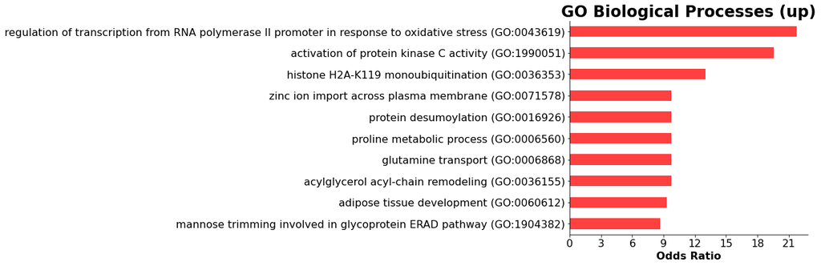

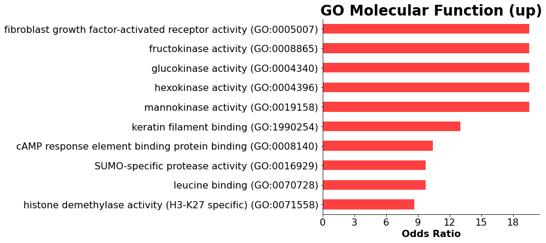

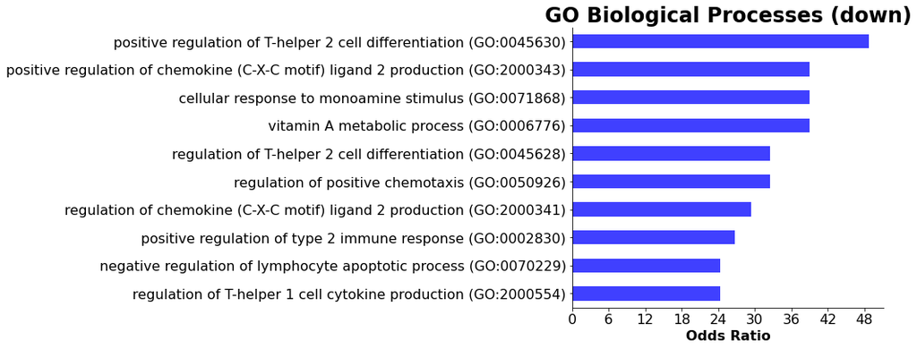

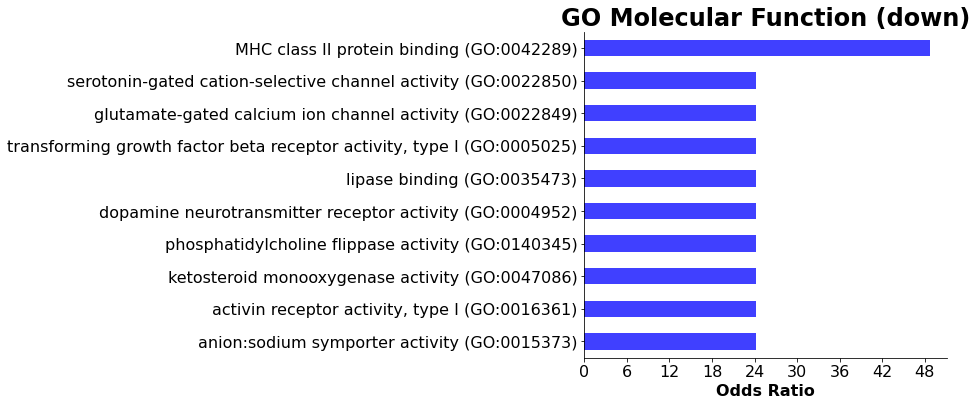

```python
#visualize the top 10 upregulated pathways in barplots, color in red
barplot(enr_GOBP_up.res2d, title='GO Biological Processes (up)', column = "Odds Ratio", color = 'r')
#visualize the top 10 upregulated molecular functinos in barplots, color in red
barplot(enr_GOMF_up.res2d, title='GO Molecular Function (up)', column = "Odds Ratio", color = 'r')
#visualize the top 10 downregulated pathways in barplots, color in blue
barplot(enr_GOBP_down.res2d,title='GO Biological Processes (down)', column = "Odds Ratio", color = 'b')
#visualize the top 10 downregulated molecular functinos in barplots, color in blue
barplot(enr_GOMF_down.res2d,title='GO Molecular Function (down)', column = "Odds Ratio", color = 'b')
```

# Part 3C: Analyzing the Result

Bar plots of pathway analysis above show the top 10 GO biological processes (pathways) and molecular function data sets. These are pathways and functions that most associated with genes that significantly upregulated (in red) and downregulated (in blue) in invasive ductal carcinoma cell lines when compare to breast ductal adenocarcinoma cell lines. Bar plots are plot using odds ratio instead of negative log10 p-value, because all queried analysis results do not exhibit significant differences (p-value >0.05). Therefore, plots exhibit the trend of changes in pathways and molecular functions, but no significantly differences between cell lines of two breast disease types.

Biological process that is most upregulated in invasive ductal carcinoma cell lines is the regulation of transcription from RNA polymerase II promoter in response to oxidative stress (GO: 0043619) with an odds ratio around 21, while the molecular function that is most enhanced is the fibroblast growth factor-activated receptor activity (GO: 0005007) with an odds ratio around 18. Biological process that is most inhibited in invasive ductal carcinoma cell lines is the positive regulation of T-helper 2 cell differentiation (GO: 0045630) with an odds ratio around 48, while the molecular function that is most downregulated is the MHC class II protein binding (GO: 0042289) with an odds ratio around 48.

The pathway analysis results here show biological processes and molecular function that potentially promote the metastasis ability of invasive ductal carcinoma cell lines, by either being upregulated or downregulated. There may also be more pathways and functions associated with observed differences between two breast cancer type but are not identified yet.

# Bibliography

Davis et al. “PTPRS Regulates Colorectal Cancer RAS Pathway Activity by Inactivating Erk and Preventing Its Nuclear Translocation.” Scientific Reports, no. 1, Springer Science and Business Media LLC, June 2018. Crossref, doi:10.1038/s41598-018-27584-x.

Hill et al. “Gene Ontology Annotations: What They Mean and Where They Come From.” BMC Bioinformatics, no. S5, Springer Science and Business Media LLC, Apr. 2008. Crossref, doi:10.1186/1471-2105-9-S5-S2.

Jafari, Mohieddin, and Naser Ansari-Pour. “Why, When and How to Adjust Your P Values?” Cell J (Yakhteh), no. 04, Royan Institute, Iranian Academic Center for Education Culture and Research (ACECR), Aug. 2018, doi:10.22074/cellj.2019.5992.

MacKeigan et al. “Sensitized RNAi Screen of Human Kinases and Phosphatases Identifies New Regulators of Apoptosis and Chemoresistance.” Nature Cell Biology, no. 6, Springer Science and Business Media LLC, May 2005, pp. 591–600. Crossref, doi:10.1038/ncb1258.

Morris et al. “Genomic Dissection of the Epidermal Growth Factor Receptor (EGFR)/PI3K Pathway Reveals Frequent Deletion of the EGFR Phosphatase PTPRS in Head and Neck Cancers.” Proceedings of the National Academy of Sciences, no. 47, Proceedings of the National Academy of Sciences, Nov. 2011, pp. 19024–29. Crossref, doi:10.1073/pnas.1111963108.

Wang et al. “Protein Tyrosine Phosphatase Receptor S Acts as a Metastatic Suppressor in Hepatocellular Carcinoma by Control of Epithermal Growth Factor Receptor-Induced Epithelial-Mesenchymal Transition.” Hepatology, no. 4, Wiley, Aug. 2015, pp. 1201–14. Crossref, doi:10.1002/hep.27911.

# Data sets sources

EBI Expression Atals: https://www.ebi.ac.uk/gxa/home

Gene Ontology: http://geneontology.org/

# Code references

RNA-seq: https://canvas.ucsd.edu/courses/35373/files/7096288?module_item_id=1375220&fd_cookie_set=1

https://docs.scipy.org/doc/scipy/reference/generated/scipy.stats.ttest_ind_from_stats.html

https://www.statsmodels.org/0.8.0/generated/statsmodels.sandbox.stats.multicomp.multipletests.html

Volcano plot: https://www.reneshbedre.com/blog/volcano.html

https://reneshbedre.github.io/blog/howtoinstall.html

Pathway analysis: https://gseapy.readthedocs.io/en/latest/gseapy_example.html#2.-Enrichr-Example

https://canvas.ucsd.edu/courses/35373/files/6482445?module_item_id=1263478&fd_cookie_set=1